# FML Assigment-5

Dharani

#Using a library function, first we are loading the necessary packages.

#Data Pre-processing

#Counting the amount of missing values and then adding or deleting them.

```r
Cereals_Data1 <- read.csv("C:/Users/DHARANI/Downloads/Cereals.csv")
Cereals1<-read.csv("C:/Users/DHARANI/Downloads/Cereals.csv")
str(Cereals_Data1)
```

```
## 'data.frame':    77 obs. of  16 variables:
##  $ name    : chr  "100%_Bran" "100%_Natural_Bran" "All-Bran" "All-Bran_with_Extra_Fiber" ...
##  $ mfr     : chr  "N" "Q" "K" "K" ...
##  $ type    : chr  "C" "C" "C" "C" ...
##  $ calories: int  70 120 70 50 110 110 110 130 90 90 ...
##  $ protein : int  4 3 4 4 2 2 2 3 2 3 ...
##  $ fat     : int  1 5 1 0 2 2 0 2 1 0 ...
##  $ sodium  : int  130 15 260 140 200 180 125 210 200 210 ...
##  $ fiber   : num  10 2 9 14 1 1.5 1 2 4 5 ...
##  $ carbo   : num  5 8 7 8 14 10.5 11 18 15 13 ...
##  $ sugars  : int  6 8 5 0 8 10 14 8 6 5 ...
##  $ potass  : int  280 135 320 330 NA 70 30 100 125 190 ...
##  $ vitamins: int  25 0 25 25 25 25 25 25 25 25 ...
##  $ shelf   : int  3 3 3 3 3 1 2 3 1 3 ...
##  $ weight  : num  1 1 1 1 1 1 1 1.33 1 1 ...
##  $ cups    : num  0.33 1 0.33 0.5 0.75 0.75 1 0.75 0.67 0.67 ...
##  $ rating  : num  68.4 34 59.4 93.7 34.4 ...
```

```r
sum(is.na(Cereals_Data1))
```

```
## [1] 4
```

#To eliminate any missing values from the data.

```r
Cereals_Data1 <- na.omit(Cereals_Data1)
Cereals1<-na.omit(Cereals1)
sum(is.na(Cereals_Data1))
```

```
## [1] 0
```

#In order to see the clusters later, translate the cereal names into row names.

```r
rownames(Cereals_Data1) <- Cereals_Data1$name
rownames(Cereals1) <- Cereals1$name
```

#The name column should be removed as it is no longer helpful.

```r
Cereals_Data1$name = NULL
Cereals1$name = NULL
```

#Since factors with greater ranges would considerably impact the distance, the data must be corrected before measuring any distance.

```r
Cereals_Data1 <- scale(Cereals_Data1[,3:15])
```

#We will use Euclidean distance to do hierarchical clustering on the data.

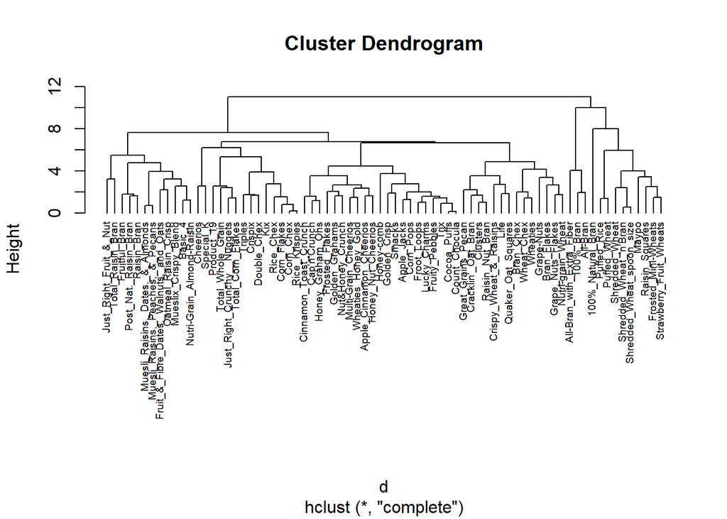

```r
# Dissimilarity matrix
d <- dist(Cereals_Data1, method = "euclidean")
# Hierarchical clustering using Complete Linkage
HC_comp <- hclust(d, method = "complete" )
# Plot the obtained dendrogram
plot(HC_comp, cex = 0.6, hang = -1)
```

#the agglomerative coefficients of each technique, in addition to clustering based on average, complete, single

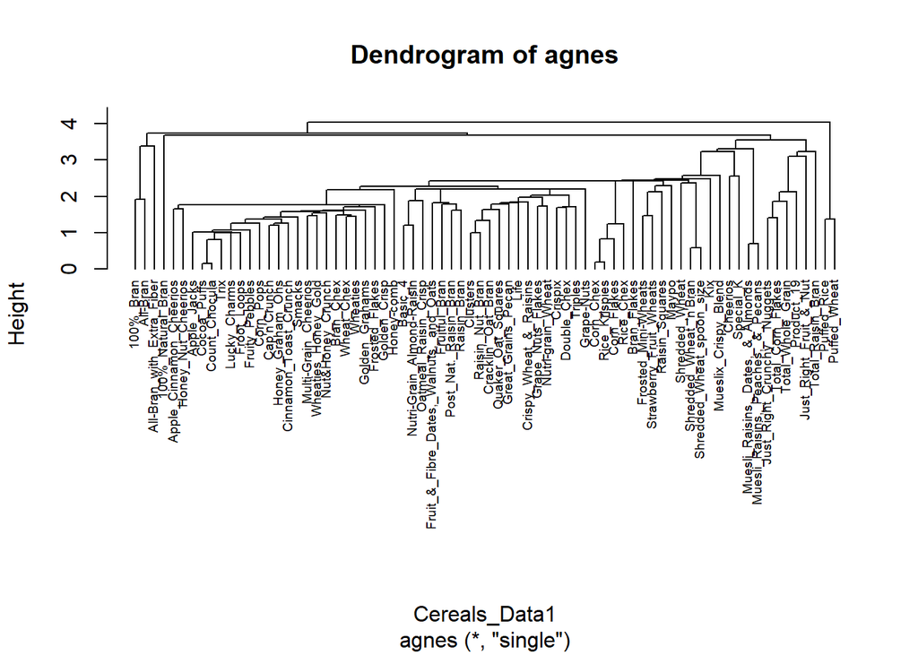

```r
library(cluster)
HC_single1 <- agnes(Cereals_Data1, method = "single")
pltree(HC_single1, cex = 0.6, hang = -1, main = "Dendrogram of agnes")
```

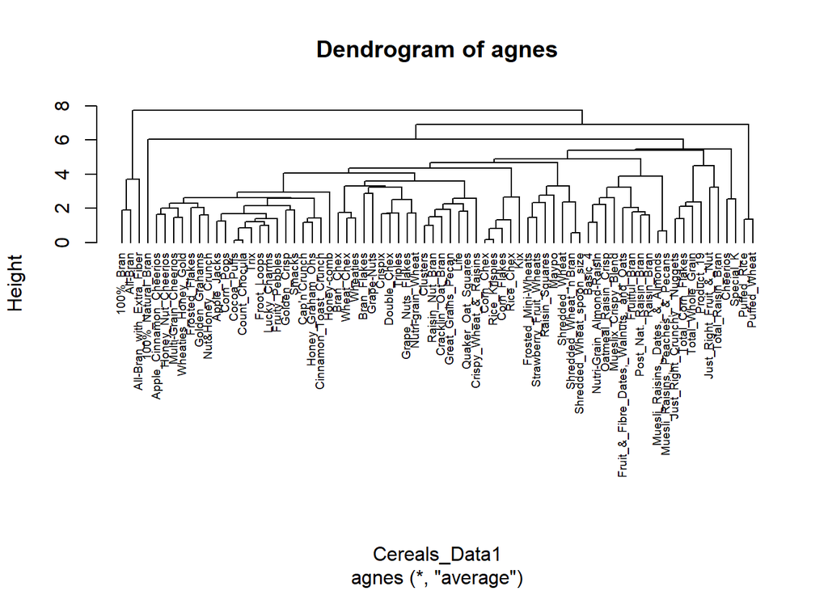

```r
HC_avg <- agnes(Cereals_Data1, method = "average")
pltree(HC_avg, cex = 0.6, hang = -1, main = "Dendrogram of agnes")
```

#We will calculate the agnes coefficient for each approach.

```r
# methods to assess
m <- c( "average", "single", "complete", "ward")
names(m) <- c( "average", "single", "complete", "ward")
# function to compute coefficient
ac <- function(x) {
  agnes(Cereals_Data1, method = x)$ac
}
map_dbl(m, ac)
```

```
##   average    single  complete      ward
## 0.7766075 0.6067859 0.8353712 0.9046042
```

#Ward is the best linking method, with an agglomerative coefficient of 0.9046042.

#Using the wards approach to visualize the dendogram:

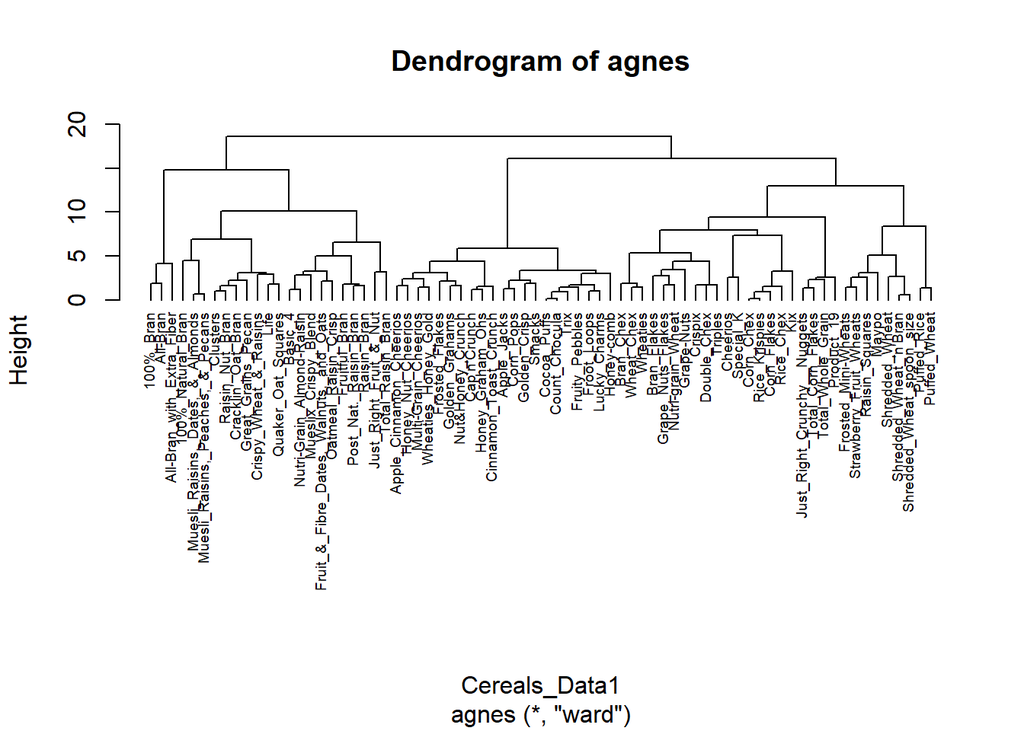

```r
HC_Wards <- agnes(Cereals_Data1, method = "ward")
pltree(HC_Wards, cex = 0.6, hang = -1, main = "Dendrogram of agnes")
```

#Cut the dendogram with cutree() to find sub-groups (i.e. clusters):

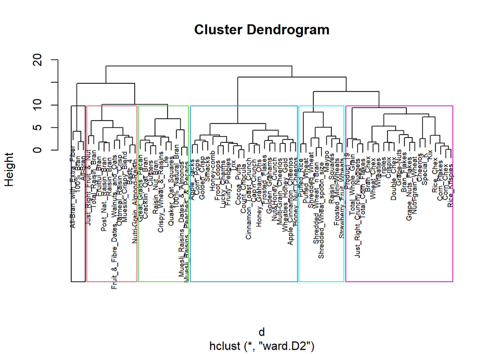

```r
#Create the distance matrix
d <- dist(Cereals_Data1, method = "euclidean")
# Ward's method for Hierarchical clustering
HC_Ward_clust <- hclust(d, method = "ward.D2" )
plot(HC_Ward_clust, cex=0.6 )
rect.hclust(HC_Ward_clust,k=6,border = 1:6)
```

#Let’s examine how many data records have been categorized and allocated to clusters:

```r
# Cut tree into 6 groups
sub_grup <- cutree(HC_Ward_clust, k = 6)
# Number of members in each cluster
table(sub_grup)
```

```
## sub_grup
##  1  2  3  4  5  6
##  3 10 21 10 21  9
```

#Correlation matrix:

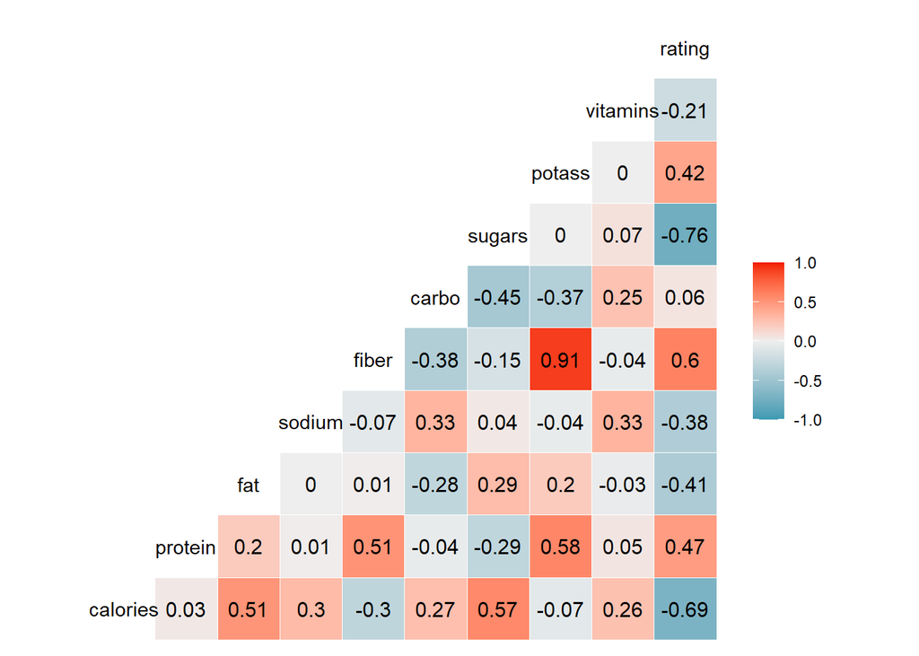

```r
#install.packages("GGally")
Cereals1 %>%
  select(calories, protein, fat, sodium, fiber, carbo, sugars, potass,vitamins,rating) %>%
  ggcorr(palette = "RdBu", label = TRUE, label_round =  2)
```

#With the use of the correlation matrix, we may ascertain if there is a strong or weak link between the variables. Our ability to compute descriptive statistics will increase.

#P-values for hierarchical clustering based on multiscale bootstrap resampling are generated by the pvclust() function of the pvclust package. Large p values will be assigned to clusters that the data strongly support. Suzuki provides interpretive advice. Recall that columns are grouped in pvclust instead of rows. Prior to utilizing your data, make sure it has been transposed.

```r
# Ward Hierarchical Clustering with Bootstrapped p values
#install.packages("pvclust")
library(pvclust)
fit.pv <- pvclust(Cereals_Data1, method.hclust="ward.D2",
               method.dist="euclidean")
```

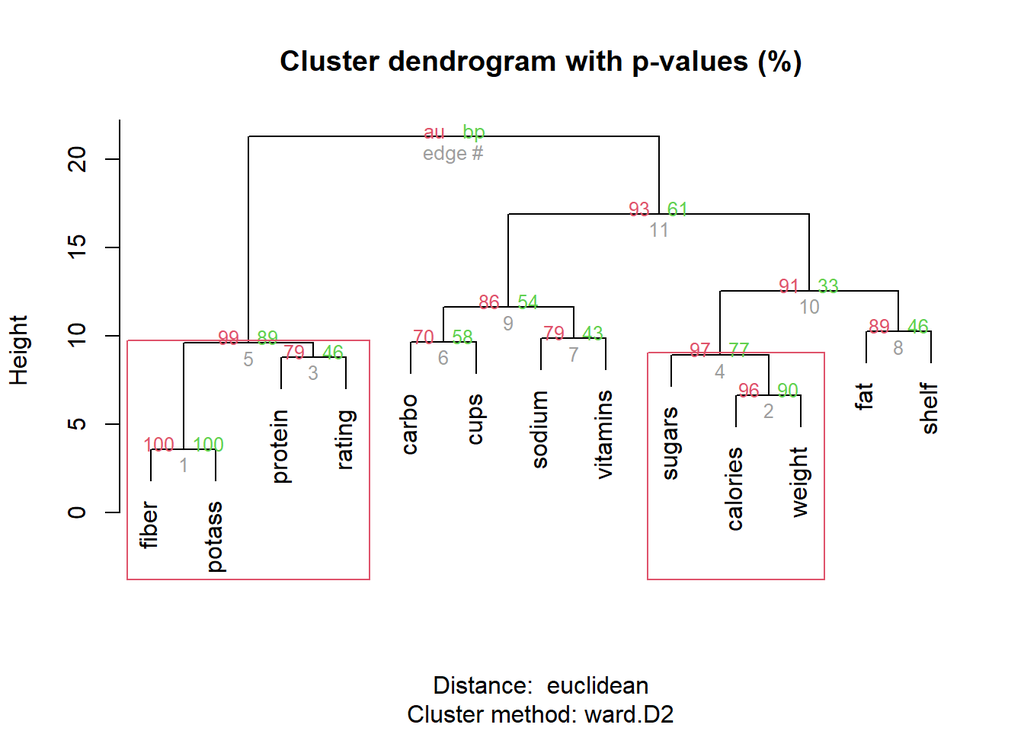

```r
plot(fit.pv) # dendogram with p values
# add rectangles around groups highly supported by the data
pvrect(fit.pv, alpha=.95)
```

#The mean value of each cluster’s Jaccard coefficient over all bootstrap rounds represents the cluster stability of each cluster in the original clustering. If a cluster’s stability score is less than 0.6, it should be regarded as unstable. There isn’t much agreement on which points belong together in the cluster, but it can detect a pattern in the data with values between 0.6 and 0.75. Clusters with stability scores greater than 0.85 are deemed highly stable.

1. The ideal approach is to maximize the cluster wise Bootstrapping Jaccard
2. Dissolved clusters ought to be limited in number.
3. More recovered clusters should be added while remaining as close together as feasible.

#Running clusterboot()

```r
library(fpc)
library(cluster)
Kbest_p<-6
cboot_hclust <- clusterboot(Cereals_Data1,clustermethod=hclustCBI,method="ward.D2", k=Kbest_p)
```

```r
summary(cboot_hclust$result)
```

```
##               Length Class  Mode
## result         7     hclust list
## noise          1     -none- logical
## nc             1     -none- numeric
## clusterlist    6     -none- list
## partition     74     -none- numeric
## clustermethod  1     -none- character
## nccl           1     -none- numeric
```

```r
groups<-cboot_hclust$result$partition
head(data.frame(groups))
```

```
##                           groups
## 100%_Bran                      1
## 100%_Natural_Bran              2
## All-Bran                       1
## All-Bran_with_Extra_Fiber      1
## Apple_Cinnamon_Cheerios        3
## Apple_Jacks                    3
```

```r
#The vector of cluster stabilities
cboot_hclust$bootmean
```

```
## [1] 0.8337256 0.5283137 0.9110611 0.6508132 0.5894548 0.6808843
```

```r
#The number of times each cluster was disintegrated. Clusterboot() executes 100 bootstrap by default.
#iterations.
cboot_hclust$bootbrd
```

```
## [1] 18 59  0 39 32 44
```

#Extracting the clusters found by hclust()

```r
groups <- cutree(HC_Ward_clust, k = 6)
print_clusters <- function(labels, k) {
for(i in 1:k) {
print(paste("cluster", i))
print(Cereals1[labels==i,c("mfr","calories","protein","fat","sodium","fiber","carbo","sugars","potass",
                "vitamins","rating")])
}
}
print_clusters(groups, 6)
```

```
## [1] "cluster 1"
##                           mfr calories protein fat sodium fiber carbo sugars
## 100%_Bran                   N       70       4   1    130    10     5      6
## All-Bran                    K       70       4   1    260     9     7      5
## All-Bran_with_Extra_Fiber   K       50       4   0    140    14     8      0
##                           potass vitamins   rating
## 100%_Bran                    280       25 68.40297
## All-Bran                     320       25 59.42551
## All-Bran_with_Extra_Fiber    330       25 93.70491
## [1] "cluster 2"
##                                   mfr calories protein fat sodium fiber carbo
## 100%_Natural_Bran                   Q      120       3   5     15   2.0   8.0
## Clusters                            G      110       3   2    140   2.0  13.0
## Cracklin'_Oat_Bran                  K      110       3   3    140   4.0  10.0
## Crispy_Wheat_&_Raisins              G      100       2   1    140   2.0  11.0
## Great_Grains_Pecan                  P      120       3   3     75   3.0  13.0
## Life                                Q      100       4   2    150   2.0  12.0
## Muesli_Raisins,_Dates,_&_Almonds    R      150       4   3     95   3.0  16.0
## Muesli_Raisins,_Peaches,_&_Pecans   R      150       4   3    150   3.0  16.0
## Quaker_Oat_Squares                  Q      100       4   1    135   2.0  14.0
## Raisin_Nut_Bran                     G      100       3   2    140   2.5  10.5
##                                   sugars potass vitamins   rating
## 100%_Natural_Bran                      8    135        0 33.98368
## Clusters                               7    105       25 40.40021
## Cracklin'_Oat_Bran                     7    160       25 40.44877
## Crispy_Wheat_&_Raisins                10    120       25 36.17620
## Great_Grains_Pecan                     4    100       25 45.81172
## Life                                   6     95       25 45.32807
## Muesli_Raisins,_Dates,_&_Almonds      11    170       25 37.13686
## Muesli_Raisins,_Peaches,_&_Pecans     11    170       25 34.13976
## Quaker_Oat_Squares                     6    110       25 49.51187
## Raisin_Nut_Bran                        8    140       25 39.70340
## [1] "cluster 3"
##                         mfr calories protein fat sodium fiber carbo sugars
## Apple_Cinnamon_Cheerios   G      110       2   2    180   1.5  10.5     10
## Apple_Jacks               K      110       2   0    125   1.0  11.0     14
## Cap'n'Crunch              Q      120       1   2    220   0.0  12.0     12
## Cinnamon_Toast_Crunch     G      120       1   3    210   0.0  13.0      9
## Cocoa_Puffs               G      110       1   1    180   0.0  12.0     13
## Corn_Pops                 K      110       1   0     90   1.0  13.0     12
```

[output cut: 111 more lines]

```
## Raisin_Squares              K       90       2   0      0     2    15      6
## Shredded_Wheat              N       80       2   0      0     3    16      0
## Shredded_Wheat_'n'Bran      N       90       3   0      0     4    19      0
## Shredded_Wheat_spoon_size   N       90       3   0      0     3    20      0
## Strawberry_Fruit_Wheats     N       90       2   0     15     3    15      5
##                           potass vitamins   rating
## Frosted_Mini-Wheats          100       25 58.34514
## Maypo                         95       25 54.85092
## Puffed_Rice                   15        0 60.75611
## Puffed_Wheat                  50        0 63.00565
## Raisin_Squares               110       25 55.33314
## Shredded_Wheat                95        0 68.23588
## Shredded_Wheat_'n'Bran       140        0 74.47295
## Shredded_Wheat_spoon_size    120        0 72.80179
## Strawberry_Fruit_Wheats       90       25 59.36399
```

Notes:

Since there is no mention of an adequate metric or scale to create a healthy diet, my decision to select clusters rich in nutritional elements and based on statistical values to make a healthy diet is entirely subjective.

The clusters have a rich, sufficient, and nutrient-poor cereal diet. The data was divided into six groupings, and these clusters will be examined in the context of all the variables and factors.

Although there are some nutritionally sound recommendations for establishing a balanced diet in Cluster 1, the selection is somewhat small. Clusters 2 and 3 have low ratings and high fat and sugar contents, thus they are not advised for a healthy supper.